# European Breast Cancer Precision-Oncology Access

Burden, biomarker-guided trials and geographic research-access gaps

Azmir Alam

12 August 2026

# 1 Executive summary

**Primary research question:** Across countries covered by the European Cancer Information System (ECIS), is the geographic distribution of sites listed for active biomarker-guided breast-cancer trials proportionate to the estimated breast-cancer burden, and which biomarkers and treatment classes are least represented?

This project links three open-data layers:

1. 2024 female breast-cancer incidence and mortality estimates from ECIS;
2. active interventional breast-cancer studies and their listed locations from ClinicalTrials.gov; and
3. a transparent text-classification dictionary for biomarkers and precision-treatment classes.

The analysis measures **research opportunity and portfolio composition**. It does not measure whether a patient actually received testing or treatment, whether a medicine is reimbursed, or whether a treatment improved survival.

# 2 1. Why this research gap matters

European precision-oncology policy increasingly emphasises next-generation sequencing, molecular tumour boards, interoperable data and trial matching. The conference evidence motivating this project describes uneven molecular-tumour-board access, testing and interpretation barriers, therapy and sequencing-coverage gaps, and the need for timely multidisciplinary review. A second conference contribution identifies health-economic evidence, workforce education, digital infrastructure, policy coordination and equitable access as priorities for pharmacogenomics.

That policy problem is not answered by another descriptive cancer-mortality ranking. A more specific open-data gap is the absence of an easily reproducible country-level analysis connecting:

- breast-cancer need (incidence and mortality);
- the geography of active biomarker-guided research;
- the biomarker and therapy portfolio being studied; and
- countries where research-site share is lower than burden share.

## 2.1 Objectives

1. Describe the 2024 breast-cancer burden across ECIS countries.
2. Identify active interventional breast-cancer studies with at least one listed ECIS-country site.
3. Classify trials by biomarker and precision-treatment class using an auditable dictionary.
4. Standardise trial and site availability by estimated incident cases.
5. quantify geographic concentration and burden–access mismatch.
6. Test whether conclusions change under a narrower recruiting-status definition.
7. Produce Tableau-ready country and trial files for continued exploration.

# 3 2. Study design and estimand

This is a cross-sectional, ecological, descriptive study using public aggregate and registry metadata. The unit of analysis is the **country** for the geographic analysis and the **NCT study** for the research-portfolio analysis.

The main estimand is:

$$\text{Listed precision-trial sites per 1,000 incident cases} =
\frac{\text{distinct listed sites in biomarker-guided therapeutic
trials}}
{\text{estimated 2024 incident breast-cancer cases}} \times 1,000$$

A complementary mismatch measure compares each country’s share of precision-trial sites with its share of incident cases:

$$\text{Access gap (percentage points)} = \text{site share} - \text{case
share}$$

Negative values identify countries with fewer listed precision-trial sites than expected if sites were distributed in proportion to estimated cases. This is a prioritisation signal, not a causal effect or a complete measure of care access.

# 4 3. Data provenance

```r
trials <- read.csv(
  "data/raw/clinicaltrials_europe_trials.csv",
  na.strings = c("", "NA"), check.names = FALSE
)
sites <- read.csv(
  "data/raw/clinicaltrials_europe_sites.csv",
  na.strings = c("", "NA"), check.names = FALSE
)
ecis <- read.csv(
  "data/raw/ecis_breast_cancer_2024.csv",
  na.strings = c("", "NA"), check.names = FALSE
)
dictionary <- read.csv(
  "data/raw/precision_oncology_dictionary.csv",
  na.strings = c("", "NA"), check.names = FALSE
)

data_inventory <- tibble(
  dataset = c("ECIS burden", "ClinicalTrials.gov studies", "Listed study sites", "Classification dictionary"),
  rows = c(nrow(ecis), nrow(trials), nrow(sites), nrow(dictionary)),
  snapshot = c(
    paste(unique(ecis$snapshot_date), collapse = ", "),
    paste(unique(trials$snapshot_date), collapse = ", "),
    paste(unique(sites$snapshot_date), collapse = ", "),
    "Version controlled"
  )
)
kable(data_inventory, caption = "Data used in this reproducible snapshot")
```

Data used in this reproducible snapshot

| dataset | rows | snapshot |
| --- | --- | --- |
| ECIS burden | 78 | 2026-08-12 |
| ClinicalTrials.gov studies | 888 | 2026-08-12 |
| Listed study sites | 16176 | 2026-08-12 |
| Classification dictionary | 15 | Version controlled |

**Interpretation.** The repository includes frozen snapshots so that the report remains reproducible. Run `Rscript scripts/download_open_data.R` to refresh the two live sources; results will change as ClinicalTrials.gov records and ECIS estimates change.

## 4.1 Data-quality checks

```r
required_trial_columns <- c(
  "nct_id", "brief_title", "overall_status", "study_type", "phase",
  "lead_sponsor", "sponsor_class", "conditions", "intervention_names",
  "intervention_types", "brief_summary", "eligibility_criteria"
)
required_site_columns <- c("nct_id", "facility", "city", "country_name", "country_code")
required_ecis_columns <- c(
  "measure_code", "country_code", "country_name", "is_group", "n_cases", "asr_e_new"
)

stopifnot(all(required_trial_columns %in% names(trials)))
stopifnot(all(required_site_columns %in% names(sites)))
stopifnot(all(required_ecis_columns %in% names(ecis)))
stopifnot(!anyDuplicated(trials$nct_id))
stopifnot(all(sites$nct_id %in% trials$nct_id))

quality <- tibble(
  check = c(
    "Unique NCT identifiers", "Sites linked to a downloaded trial",
    "ECIS country-measure duplicates", "Sites missing facility name",
    "Sites missing coordinates"
  ),
  result = c(
    n_distinct(trials$nct_id),
    sum(sites$nct_id %in% trials$nct_id),
    sum(duplicated(ecis[c("country_code", "measure_code")])),
    sum(is.na(sites$facility)),
    sum(is.na(sites$latitude) | is.na(sites$longitude))
  )
)
kable(quality, caption = "Core validation checks")
```

Core validation checks

| check | result |
| --- | --- |
| Unique NCT identifiers | 888 |
| Sites linked to a downloaded trial | 16176 |
| ECIS country-measure duplicates | 0 |
| Sites missing facility name | 0 |
| Sites missing coordinates | 197 |

**Interpretation.** Missing facility names or coordinates do not remove a country-level location if its country is known. Location records do not reliably indicate whether each individual site is presently open; this report therefore says **listed site**, never “currently recruiting site.”

# 5 4. Stage I — European breast-cancer burden

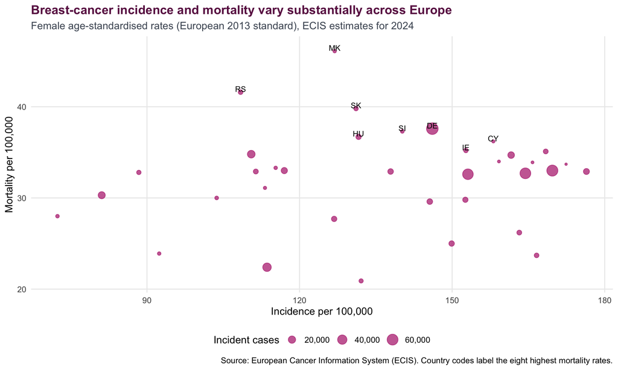

```r
burden <- ecis |>
  filter(as.character(is_group) == "0") |>
  mutate(
    n_cases = as.numeric(n_cases),
    asr_e_new = as.numeric(asr_e_new),
    crude_rate = as.numeric(crude_rate),
    cumulative_risk = as.numeric(cumulative_risk)
  ) |>
  select(
    country_code, country_name, measure_code, estimation_method,
    n_cases, asr_e_new, crude_rate, cumulative_risk
  ) |>
  pivot_wider(
    names_from = measure_code,
    values_from = c(n_cases, asr_e_new, crude_rate, cumulative_risk, estimation_method),
    names_glue = "{measure_code}_{.value}"
  ) |>
  mutate(
    mortality_incidence_ratio = MO_asr_e_new / IN_asr_e_new
  )

burden_plot <- ggplot(burden, aes(IN_asr_e_new, MO_asr_e_new)) +
  geom_point(aes(size = IN_n_cases), color = "#b83280", alpha = 0.75) +
  geom_text(
    data = burden |> slice_max(MO_asr_e_new, n = 8),
    aes(label = country_code), nudge_y = 0.35, size = 3.2
  ) +
  scale_size_continuous(labels = comma, name = "Incident cases") +
  labs(
    title = "Breast-cancer incidence and mortality vary substantially across Europe",
    subtitle = "Female age-standardised rates (European 2013 standard), ECIS estimates for 2024",
    x = "Incidence per 100,000", y = "Mortality per 100,000",
    caption = "Source: European Cancer Information System (ECIS). Country codes label the eight highest mortality rates."
  )

ggsave("visuals/01_breast_cancer_burden.png", burden_plot, width = 10, height = 6, dpi = 300, bg = "white")
burden_plot
```

```r
burden |>
  arrange(desc(MO_asr_e_new)) |>
  transmute(
    Country = country_name,
    `Incident cases` = IN_n_cases,
    `Incidence ASR` = IN_asr_e_new,
    `Deaths` = MO_n_cases,
    `Mortality ASR` = MO_asr_e_new,
    `Mortality/incidence rate ratio` = round(mortality_incidence_ratio, 3)
  ) |>
  head(12) |>
  kable(caption = "Countries with the highest estimated breast-cancer mortality rates")
```

Countries with the highest estimated breast-cancer mortality rates

| Country | Incident cases | Incidence ASR | Deaths | Mortality ASR | Mortality/incidence rate ratio |
| --- | --- | --- | --- | --- | --- |
| Republic of North Macedonia | 1222 | 126.9 | 429 | 46.1 | 0.363 |
| Serbia | 4374 | 108.4 | 1744 | 41.6 | 0.384 |
| Slovakia | 3803 | 131.1 | 1171 | 39.8 | 0.304 |
| Germany | 71600 | 146.1 | 20786 | 37.6 | 0.257 |
| Slovenia | 1655 | 140.2 | 496 | 37.3 | 0.266 |
| Hungary | 7448 | 131.6 | 2196 | 36.7 | 0.279 |
| Cyprus | 700 | 158.1 | 159 | 36.2 | 0.229 |
| Ireland | 3663 | 152.7 | 810 | 35.2 | 0.231 |
| Denmark | 5242 | 168.4 | 1203 | 35.1 | 0.208 |
| Poland | 23238 | 110.5 | 7664 | 34.8 | 0.315 |
| Netherlands | 15155 | 161.6 | 3463 | 34.7 | 0.215 |
| Luxembourg | 493 | 159.2 | 104 | 34.0 | 0.214 |

**Interpretation.** Incidence and mortality rates capture different dimensions of need. The mortality-to-incidence rate ratio is only an ecological descriptive indicator; it is not equivalent to survival because the numerator and denominator are cross-sectional estimates and may reflect screening, diagnostic practices, age structure, registry inputs and estimation methods.

# 6 5. Stage II — Identify biomarker-guided therapeutic trials

The classification is transparent and reproducible. A trial is called biomarker-guided when at least one dictionary pattern appears in its title, conditions, summary, eligibility criteria or intervention names. The primary analytic set further requires a drug, biological or genetic intervention. Multiple biomarker and treatment labels are allowed for one study.

```r
trials <- trials |>
  mutate(
    broad_text = str_to_lower(paste(
      brief_title, conditions, brief_summary, eligibility_criteria, intervention_names,
      sep = " | "
    )),
    strict_text = str_to_lower(paste(
      brief_title, conditions, eligibility_criteria, intervention_names,
      sep = " | "
    )),
    therapeutic_intervention = str_detect(
      coalesce(intervention_types, ""), "DRUG|BIOLOGICAL|GENETIC"
    )
  )

classify_trials <- function(data, dictionary_rows, text_column = "broad_text") {
  map_dfr(seq_len(nrow(dictionary_rows)), function(i) {
    data |>
      transmute(
        nct_id,
        label = dictionary_rows$label[i],
        hit = str_detect(
          .data[[text_column]],
          regex(dictionary_rows$pattern[i], ignore_case = TRUE)
        )
      ) |>
      filter(hit) |>
      select(-hit)
  }) |>
    distinct()
}

biomarker_hits <- classify_trials(
  trials, filter(dictionary, domain == "biomarker"), "broad_text"
)
strict_biomarker_hits <- classify_trials(
  trials, filter(dictionary, domain == "biomarker"), "strict_text"
)
therapy_hits <- classify_trials(
  trials, filter(dictionary, domain == "therapy"), "broad_text"
)

trials <- trials |>
  mutate(
    biomarker_guided = nct_id %in% biomarker_hits$nct_id,
    strict_biomarker_guided = nct_id %in% strict_biomarker_hits$nct_id,
    precision_therapeutic = biomarker_guided & therapeutic_intervention,
    narrow_recruiting_status = overall_status %in% c("RECRUITING", "NOT_YET_RECRUITING")
  )

classification_summary <- trials |>
  summarise(
    `All active interventional studies with a listed ECIS-country site` = n(),
    `Biomarker-guided studies` = sum(biomarker_guided),
    `Biomarker-guided therapeutic studies (primary set)` = sum(precision_therapeutic),
    `Primary-set studies recruiting or not yet recruiting` = sum(precision_therapeutic & narrow_recruiting_status)
  ) |>
  pivot_longer(everything(), names_to = "Definition", values_to = "Studies")

kable(classification_summary, caption = "Progressive construction of the analytic trial set")
```

Progressive construction of the analytic trial set

| Definition | Studies |
| --- | --- |
| All active interventional studies with a listed ECIS-country site | 888 |
| Biomarker-guided studies | 560 |
| Biomarker-guided therapeutic studies (primary set) | 394 |
| Primary-set studies recruiting or not yet recruiting | 191 |

**Interpretation.** Dictionary-based classification makes a large registry auditable, but it is not equivalent to expert review of every protocol. The strict and status-restricted sensitivity analyses below show whether the main country pattern depends strongly on classification wording or study status.

# 7 6. Stage III — Biomarker and treatment portfolio

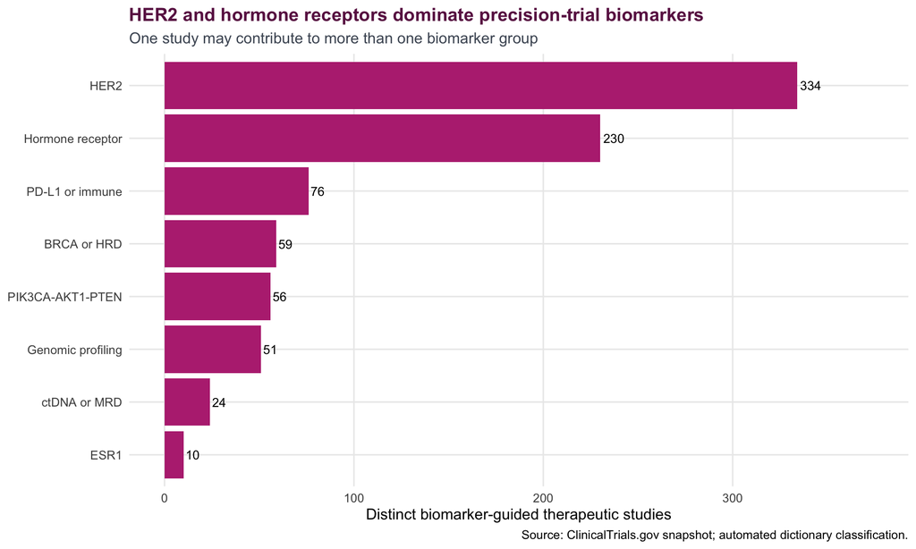

```r
biomarker_counts <- biomarker_hits |>
  semi_join(filter(trials, precision_therapeutic), by = "nct_id") |>
  count(label, name = "trials", sort = TRUE)

biomarker_plot <- ggplot(biomarker_counts, aes(trials, reorder(label, trials))) +
  geom_col(fill = "#b83280") +
  geom_text(aes(label = trials), hjust = -0.15, size = 3.5) +
  expand_limits(x = max(biomarker_counts$trials) * 1.12) +
  labs(
    title = "HER2 and hormone receptors dominate precision-trial biomarkers",
    subtitle = "One study may contribute to more than one biomarker group",
    x = "Distinct biomarker-guided therapeutic studies", y = NULL,
    caption = "Source: ClinicalTrials.gov snapshot; automated dictionary classification."
  )

ggsave("visuals/04_biomarker_portfolio.png", biomarker_plot, width = 9, height = 5.5, dpi = 300, bg = "white")
biomarker_plot
```

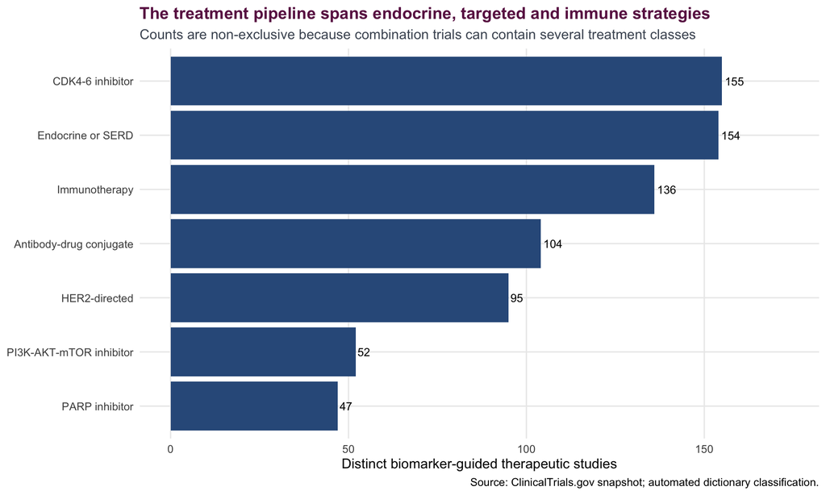

```r
therapy_counts <- therapy_hits |>
  semi_join(filter(trials, precision_therapeutic), by = "nct_id") |>
  count(label, name = "trials", sort = TRUE)

therapy_plot <- ggplot(therapy_counts, aes(trials, reorder(label, trials))) +
  geom_col(fill = "#315b8a") +
  geom_text(aes(label = trials), hjust = -0.15, size = 3.5) +
  expand_limits(x = max(therapy_counts$trials) * 1.12) +
  labs(
    title = "The treatment pipeline spans endocrine, targeted and immune strategies",
    subtitle = "Counts are non-exclusive because combination trials can contain several treatment classes",
    x = "Distinct biomarker-guided therapeutic studies", y = NULL,
    caption = "Source: ClinicalTrials.gov snapshot; automated dictionary classification."
  )

ggsave("visuals/05_therapy_portfolio.png", therapy_plot, width = 9, height = 5.5, dpi = 300, bg = "white")
therapy_plot
```

**Interpretation.** Portfolio counts reveal what is being studied, not what is routinely available. Low counts may reflect mature standard-of-care treatments, alternative registry terminology or a true research gap. The categories are non-exclusive and should be read as a portfolio map rather than a league table of treatment value.

# 8 7. Stage IV — Country-level burden and listed research sites

```r
precision_trials <- trials |> filter(precision_therapeutic)

country_sites <- sites |>
  semi_join(precision_trials, by = "nct_id") |>
  mutate(
    site_key = paste(
      nct_id, coalesce(facility, "facility-not-reported"),
      coalesce(city, "city-not-reported"), country_code, sep = "::"
    )
  ) |>
  group_by(country_code, country_name) |>
  summarise(
    precision_trials = n_distinct(nct_id),
    listed_precision_sites = n_distinct(site_key),
    .groups = "drop"
  )

all_country_trials <- sites |>
  group_by(country_code, country_name) |>
  summarise(all_active_trials = n_distinct(nct_id), .groups = "drop")

country_access <- burden |>
  left_join(country_sites, by = c("country_code", "country_name")) |>
  left_join(all_country_trials, by = c("country_code", "country_name")) |>
  mutate(
    across(c(precision_trials, listed_precision_sites, all_active_trials), ~ replace_na(.x, 0)),
    precision_trials_per_1000_cases = 1000 * precision_trials / IN_n_cases,
    precision_sites_per_1000_cases = 1000 * listed_precision_sites / IN_n_cases,
    case_share = IN_n_cases / sum(IN_n_cases),
    site_share = listed_precision_sites / sum(listed_precision_sites),
    access_gap_pp = 100 * (site_share - case_share)
  )

country_access |>
  arrange(desc(precision_sites_per_1000_cases)) |>
  transmute(
    Country = country_name,
    `Incident cases` = IN_n_cases,
    `Precision trials` = precision_trials,
    `Listed sites` = listed_precision_sites,
    `Sites per 1,000 cases` = round(precision_sites_per_1000_cases, 2),
    `Access gap (pp)` = round(access_gap_pp, 2)
  ) |>
  head(15) |>
  kable(caption = "Highest listed precision-trial site density relative to estimated burden")
```

Highest listed precision-trial site density relative to estimated burden

| Country | Incident cases | Precision trials | Listed sites | Sites per 1,000 cases | Access gap (pp) |
| --- | --- | --- | --- | --- | --- |
| Spain | 31226 | 212 | 2576 | 82.50 | 12.42 |
| Belgium | 10928 | 117 | 614 | 56.19 | 2.20 |
| Austria | 5623 | 51 | 254 | 45.17 | 0.67 |
| Ireland | 3663 | 32 | 157 | 42.86 | 0.37 |
| Hungary | 7448 | 61 | 256 | 34.37 | 0.29 |
| Netherlands | 15155 | 74 | 507 | 33.45 | 0.48 |
| France | 62713 | 203 | 2071 | 33.02 | 1.80 |
| Greece | 8733 | 43 | 266 | 30.46 | 0.08 |
| Portugal | 9100 | 57 | 259 | 28.46 | -0.05 |
| Germany | 71600 | 145 | 2028 | 28.32 | -0.46 |
| Czechia | 7598 | 44 | 195 | 25.66 | -0.20 |
| Italy | 56432 | 168 | 1448 | 25.66 | -1.48 |
| Poland | 23238 | 91 | 590 | 25.39 | -0.66 |
| Switzerland | 7228 | 39 | 167 | 23.10 | -0.33 |
| Bulgaria | 3559 | 23 | 75 | 21.07 | -0.22 |

**Interpretation.** Country size strongly affects raw counts, so standardised site and trial densities are more informative for geographic comparison. Very small countries can have unstable ratios: one multinational site may produce a high density despite limited overall infrastructure.

## 8.1 Map of listed precision-trial site density

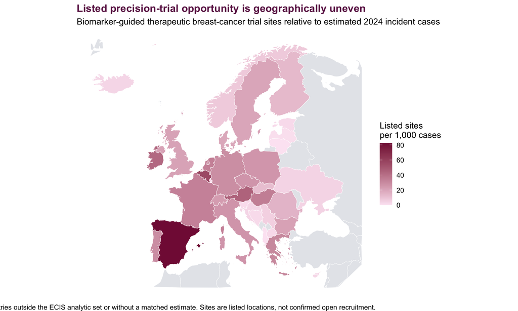

```r
map_crosswalk <- tibble(
  country_name = country_access$country_name,
  map_region = recode(
    country_access$country_name,
    "United Kingdom" = "UK",
    "Czechia" = "Czech Republic",
    "Republic of North Macedonia" = "North Macedonia",
    .default = country_access$country_name
  )
)

world <- map_data("world")
map_values <- country_access |>
  left_join(map_crosswalk, by = "country_name") |>
  select(map_region, precision_sites_per_1000_cases)

access_map <- world |>
  left_join(map_values, by = c("region" = "map_region")) |>
  filter(long > -25, long < 45, lat > 33, lat < 72) |>
  ggplot(aes(long, lat, group = group, fill = precision_sites_per_1000_cases)) +
  geom_polygon(color = "white", linewidth = 0.2) +
  coord_quickmap() +
  scale_fill_gradient(
    low = "#fce7f3", high = "#831843", na.value = "#e5e7eb",
    name = "Listed sites\nper 1,000 cases"
  ) +
  labs(
    title = "Listed precision-trial opportunity is geographically uneven",
    subtitle = "Biomarker-guided therapeutic breast-cancer trial sites relative to estimated 2024 incident cases",
    caption = "Grey indicates countries outside the ECIS analytic set or without a matched estimate. Sites are listed locations, not confirmed open recruitment."
  ) +
  theme_void(base_size = 12) +
  theme(
    plot.title = element_text(face = "bold", color = "#6b1d52"),
    legend.position = "right"
  )

ggsave("visuals/02_precision_trial_sites_map.png", access_map, width = 10, height = 7, dpi = 300, bg = "white")
access_map
```

**Interpretation.** The map is a research-access proxy. It cannot show cross-border participation, referral networks, travel time, national testing pathways, reimbursement or whether an individual site is accepting participants.

# 9 8. Stage V — Burden–access mismatch

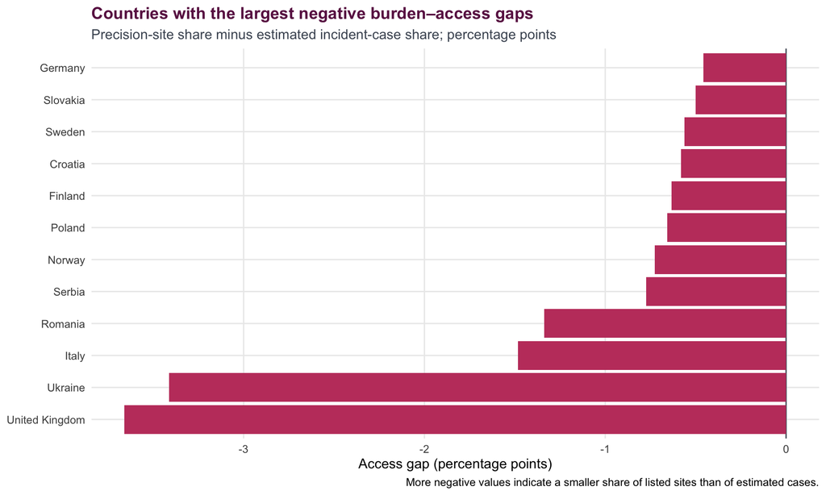

```r
gap_data <- country_access |>
  arrange(access_gap_pp) |>
  slice_head(n = 12)

gap_plot <- ggplot(gap_data, aes(access_gap_pp, reorder(country_name, access_gap_pp))) +
  geom_vline(xintercept = 0, color = "#4b5563", linewidth = 0.5) +
  geom_col(aes(fill = access_gap_pp < 0), show.legend = FALSE) +
  scale_fill_manual(values = c("FALSE" = "#2563eb", "TRUE" = "#c2416c")) +
  labs(
    title = "Countries with the largest negative burden–access gaps",
    subtitle = "Precision-site share minus estimated incident-case share; percentage points",
    x = "Access gap (percentage points)", y = NULL,
    caption = "More negative values indicate a smaller share of listed sites than of estimated cases."
  )

ggsave("visuals/03_burden_access_gap.png", gap_plot, width = 9, height = 6, dpi = 300, bg = "white")
gap_plot
```

```r
gini <- function(x) {
  x <- sort(x[is.finite(x) & x >= 0])
  if (length(x) == 0 || sum(x) == 0) return(NA_real_)
  n <- length(x)
  (2 * sum(seq_len(n) * x) / (n * sum(x))) - (n + 1) / n
}

association <- suppressWarnings(cor.test(
  country_access$IN_n_cases,
  country_access$listed_precision_sites,
  method = "spearman", exact = FALSE
))

metrics <- tibble(
  Metric = c(
    "Countries with no listed precision-therapeutic site",
    "Spearman correlation: incident cases vs listed sites",
    "Gini concentration: estimated incident cases",
    "Gini concentration: listed precision sites"
  ),
  Value = c(
    sum(country_access$listed_precision_sites == 0),
    round(unname(association$estimate), 3),
    round(gini(country_access$IN_n_cases), 3),
    round(gini(country_access$listed_precision_sites), 3)
  )
)
kable(metrics, caption = "Geographic alignment and concentration diagnostics")
```

Geographic alignment and concentration diagnostics

| Metric | Value |
| --- | --- |
| Countries with no listed precision-therapeutic site | 2.000 |
| Spearman correlation: incident cases vs listed sites | 0.931 |
| Gini concentration: estimated incident cases | 0.647 |
| Gini concentration: listed precision sites | 0.740 |

**Interpretation.** A positive correlation is expected because larger countries have more cases and more research centres. The gap and Gini statistics ask the harder question: whether research locations are more concentrated than disease burden. They remain descriptive and should guide deeper country investigation, not rank health-system quality.

# 10 9. Stage VI — Sensitivity analyses

Two decisions could change the result: inclusion of active-but-not-recruiting studies and use of the broad text corpus. We recompute country coverage with (a) only recruiting/not-yet-recruiting studies and (b) the stricter biomarker classification that excludes the free-text summary.

```r
narrow_nct <- trials |>
  filter(precision_therapeutic, narrow_recruiting_status) |>
  pull(nct_id)

strict_nct <- trials |>
  filter(
    strict_biomarker_guided,
    therapeutic_intervention
  ) |>
  pull(nct_id)

sensitivity_country <- function(nct_ids, metric_name) {
  sites |>
    filter(nct_id %in% nct_ids) |>
    group_by(country_code) |>
    summarise(value = n_distinct(nct_id), .groups = "drop") |>
    right_join(select(burden, country_code), by = "country_code") |>
    mutate(value = replace_na(value, 0), definition = metric_name)
}

sensitivity_results <- bind_rows(
  sensitivity_country(precision_trials$nct_id, "Primary broad definition"),
  sensitivity_country(narrow_nct, "Recruiting/not-yet-recruiting only"),
  sensitivity_country(strict_nct, "Strict text definition")
) |>
  group_by(definition) |>
  summarise(
    studies = n_distinct(c(
      if (definition[1] == "Primary broad definition") precision_trials$nct_id
      else if (definition[1] == "Recruiting/not-yet-recruiting only") narrow_nct
      else strict_nct
    )),
    countries_with_at_least_one_trial = sum(value > 0),
    countries_with_zero_trials = sum(value == 0),
    .groups = "drop"
  )

kable(sensitivity_results, caption = "Sensitivity of country coverage to analytic definitions")
```

Sensitivity of country coverage to analytic definitions

| definition | studies | countries_with_at_least_one_trial | countries_with_zero_trials |
| --- | --- | --- | --- |
| Primary broad definition | 394 | 34 | 2 |
| Recruiting/not-yet-recruiting only | 191 | 26 | 10 |
| Strict text definition | 388 | 34 | 2 |

**Interpretation.** If country coverage changes sharply, the geographic conclusion is sensitive to registry status or text-classification choices. This uncertainty should be carried forward rather than hidden behind a single precise ranking.

# 11 10. Reproducible outputs

```r
trial_catalogue <- precision_trials |>
  select(
    nct_id, brief_title, overall_status, phase, lead_sponsor, sponsor_class,
    intervention_names, intervention_types, start_date, completion_date,
    last_update_post_date, snapshot_date
  ) |>
  left_join(
    biomarker_hits |>
      group_by(nct_id) |>
      summarise(biomarkers = paste(sort(unique(label)), collapse = " | "), .groups = "drop"),
    by = "nct_id"
  ) |>
  left_join(
    therapy_hits |>
      group_by(nct_id) |>
      summarise(therapy_classes = paste(sort(unique(label)), collapse = " | "), .groups = "drop"),
    by = "nct_id"
  )

write.csv(country_access, "data/processed/tableau_country_access.csv", row.names = FALSE, na = "")
write.csv(trial_catalogue, "data/processed/precision_trial_catalogue.csv", row.names = FALSE, na = "")
write.csv(biomarker_counts, "data/processed/biomarker_trial_counts.csv", row.names = FALSE, na = "")
write.csv(therapy_counts, "data/processed/therapy_trial_counts.csv", row.names = FALSE, na = "")
write.csv(
  sites |> semi_join(precision_trials, by = "nct_id"),
  "data/processed/listed_precision_trial_sites.csv", row.names = FALSE, na = ""
)

outputs <- tibble(
  file = c(
    "tableau_country_access.csv", "precision_trial_catalogue.csv",
    "biomarker_trial_counts.csv", "therapy_trial_counts.csv",
    "listed_precision_trial_sites.csv"
  ),
  purpose = c(
    "Country burden and access dashboard", "Auditable trial-level catalogue",
    "Biomarker portfolio chart", "Therapy portfolio chart", "Site map or point layer"
  )
)
kable(outputs, caption = "Generated analysis files in data/processed/")
```

Generated analysis files in data/processed/

| file | purpose |
| --- | --- |
| tableau_country_access.csv | Country burden and access dashboard |
| precision_trial_catalogue.csv | Auditable trial-level catalogue |
| biomarker_trial_counts.csv | Biomarker portfolio chart |
| therapy_trial_counts.csv | Therapy portfolio chart |
| listed_precision_trial_sites.csv | Site map or point layer |

# 12 11. Conclusions and next research stages

This analysis identifies countries where breast-cancer research opportunity appears low relative to estimated disease burden and shows which biomarker/treatment areas dominate active interventional research. It creates a reproducible screening tool for more detailed health-services research.

The next stages require additional data that should not be inferred from trial registries:

1. **Testing readiness:** national availability, turnaround time and reimbursement for HER2, germline/somatic BRCA, PIK3CA, ESR1 and comprehensive genomic profiling.
2. **Treatment access:** EMA authorisation linked to country reimbursement decisions, time to access and clinical guideline uptake.
3. **Molecular tumour boards:** coverage, referral criteria, actionability rates and trial-matching outcomes.
4. **Equity:** travel time, rurality, socioeconomic deprivation, age and minority representation.
5. **Patient outcomes:** protected patient-level or registry-linked designs evaluating treatment receipt and survival with appropriate confounding control.

**Do not interpret this report as evidence that trial-rich countries deliver better care or that a listed therapy is clinically appropriate.** Trial metadata, estimated cancer burden and country-level indicators cannot establish individual eligibility, access, treatment effectiveness or causal effects.

# 13 12. Limitations

- ECIS values are modelled country estimates and methods vary by country.
- ClinicalTrials.gov is not the only European trial registry, and record completeness varies.
- A listed location may not currently recruit; site status is not consistently available in the downloaded location metadata.
- Facility deduplication is based on study, facility, city and country strings.
- Automated pattern matching can create false positives and false negatives.
- Site counts do not measure enrolment capacity, travel time, referral pathways or cross-border access.
- Small-country rates can be unstable.
- The cross-sectional design cannot assess trends in access or patient outcomes.

The frozen source files record their snapshot dates and source URLs. For a fully documented refresh, run the downloader first and then knit this report from the repository root.